# IE48A HW2

Alican Yılmaz

8/17/2020

# Assignment 2: Electricity Market Prices

## Terminology about Electricity Market Prices

- Key idea behind the electricity markets is “balance”.
- Some of the markets are named as:
  - Day Ahead Market - DAM (Gün Öncesi Piyasası - GÖP)
  - Intraday Market - IDM (Gün İçi Piyasası - GİP)
  - Balancing Power Market - BPM (Dengeleme Güç Piyasası - DGP).
- Electricity market (in Turkey) is hourly.
- MCP means “Market Clearing Price” and “SMP means System Marginal Price” and MCP and SMP abbreviations will be used,respectively, to refer them.
- SMP is always higher than MCP if system has Energy Deficit, and lower if there is Energy Surplus. Market operator also penalizes the operations in BPM by 3%. This is called Imbalance Price. Negative (Deficit) Imbalance Price is calculated as max(MCP,SMP)1.03 and Positive Imbalance Price is calculated as min(MCP,SMP)0.97.

*Important Note:* The source of the data that I used in following parts is [EPİAS Web Page](https://rapor.epias.com.tr/rapor/xhtml/ptfSmfListeleme.xhtml). You can find more information from the website.

## Data Preprocessing

**1.** First, I need to extract the data that I will work on. For that, I will use `dplyr`. After the investigation of the data, I realized date column is of type “character”. So before geting to work on, I need to convert it to “date” type.

```r
new_data <- raw_df
#convert the character column to date column
new_data$Date <- strptime(new_data$Date,format="%d.%m.%y %H:%M")
#select the related columns
new_data2<- new_data %>%
   select(Date,MCP,SMP) %>%
   pivot_longer(.,-Date)

#head(new_data2)

new_data2%>%
  glimpse()
```

```
## Rows: 1,488
## Columns: 3
## $ Date  <dttm> 2020-07-01 00:00:00, 2020-07-01 00:00:00, 2020-07-01 01:00:0...
## $ name  <chr> "MCP", "SMP", "MCP", "SMP", "MCP", "SMP", "MCP", "SMP", "MCP"...
## $ value <dbl> 323.85, 211.00, 326.95, 201.00, 324.31, 211.00, 322.11, 211.0...
```

## Exploring and Analyzing Data

**2.** Now, I am ready to visualize for a better insight about the data. For that, I will use `ggplot2`.Below you can see MCP vs SMP hourly price changes on “1st of July 2020”.

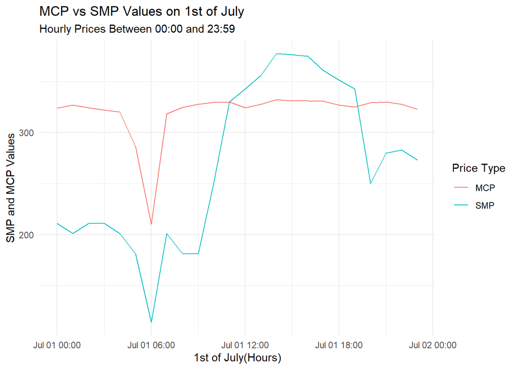

```r
  daily_sample<-new_data2 %>%
    filter(Date<"2020-07-02 00:00:00")

  line_plot<-ggplot(daily_sample, aes(as.POSIXct(Date),value,color=name)) + geom_line()

  line_plot2<-line_plot+theme_minimal()
  line_plot3 <- line_plot2 + labs(x="1st of July(Hours)", y="SMP and MCP Values", color="Price Type", title = "MCP vs SMP Values on 1st of July", subtitle = "Hourly Prices Between 00:00 and 23:59")

line_plot3
```

From the line plot, we can observe that, On July 1st, a correlation exists between SMP and MCP values from 00.00 until 11.00. Still MCP values are higher than SMP values between the hours, which implies an energy surplus. From 11.00 til 19.00 SMP values surpass MCP values which indicates energy deficit of the system. Also, it can be observed that MCP values tend to be stabilized after 07.00 A.M.

**2.1.** Similarly, we can use histogram for a better understanding.

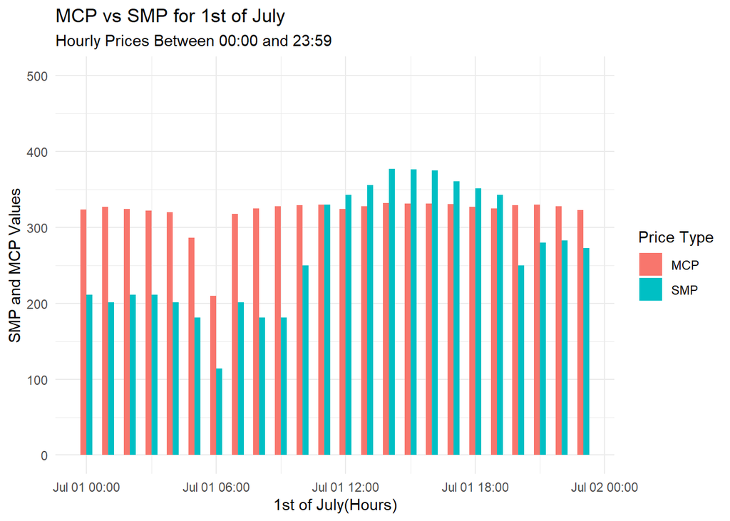

```r
  daily_sample<-new_data2 %>%
    filter(Date<"2020-07-02 00:00:00")

  bar_plot<-ggplot(daily_sample, aes(as.POSIXct(Date),value,fill=name)) + geom_col(width=2000,position="dodge")

  bar_plot2<-bar_plot+theme_minimal()

  bar_plot3 <- bar_plot2 + labs(x="1st of July(Hours)", y="SMP and MCP Values",fill="Price Type", title = "MCP vs SMP for 1st of July", subtitle = "Hourly Prices Between 00:00 and 23:59") +ylim(0,500)

bar_plot3
```

**3.** Let’s investigate MCP/SMP distribution over different price values.

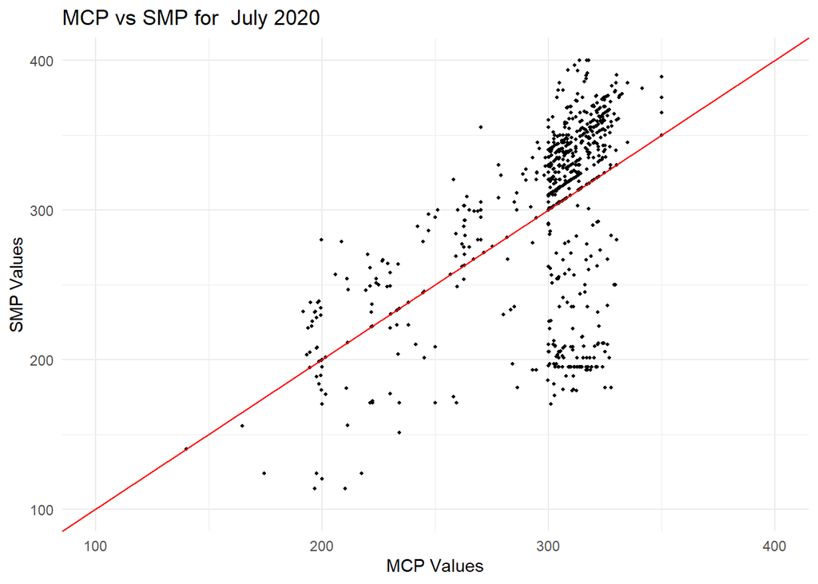

```r
  #new_data

  scatter_plot<-ggplot(new_data,aes(x=MCP,y=SMP)) + geom_point(alpha=1,size=0.8)+ geom_abline(slope=1, intercept=0, color="red")

  scatter_plot<-scatter_plot+theme(aspect.ratio=1)+ xlim(100,400) + ylim(100,400)

  scatter_plot2 <- scatter_plot + labs(x="MCP Values", y="SMP Values", title = "MCP vs SMP for  July 2020")+theme_minimal()

scatter_plot2
## Warning: Removed 21 rows containing missing values (geom_point).
```

From the scatter plot, we can observe that SMP values tend to be higher than MCP values after the threshold point of 300, which means system tends to have energy deficit after that point.

**4.** Let’s do some math now! Suppose we investigate hourly MCP and SMP values along with percentage changes in July 2020. For that, we first need to filter our data accordingly. We will get the help of `dplyr` and `ggplot2` for our aim.

```r
  #create an extra hour column
  new_data$hour <- as.POSIXlt(new_data$Date)$hour
  new_data3<-new_data %>%
   #select licenced biomass
   select(Date,MCP,SMP,hour) %>%
   #group by day
   group_by(hour)%>%
   #find hourly average for both SMP AND MCP
   summarise(hourly_avg_MCP=mean(MCP),hourly_avg_SMP=mean(SMP)) %>%
   # CALCULATION OF PERCENTAGE CHANGE


   #add lag  column
   mutate(hourly_lag_MCP = lag(hourly_avg_MCP,1),hourly_lag_SMP=lag(hourly_avg_SMP,1))%>%
   #find average hourly percentage change
   mutate(perc_change_MCP=hourly_avg_MCP/hourly_lag_MCP-1,perc_change_SMP=hourly_avg_SMP/hourly_lag_SMP-1)

   new_data3
```

```
## # A tibble: 24 x 7
##     hour hourly_avg_MCP hourly_avg_SMP hourly_lag_MCP hourly_lag_SMP
##    <int>          <dbl>          <dbl>          <dbl>          <dbl>
##  1     0           297.           294.            NA             NA
##  2     1           306.           308.           297.           294.
##  3     2           298.           297.           306.           308.
##  4     3           284.           283.           298.           297.
##  5     4           285.           280.           284.           283.
##  6     5           247.           248.           285.           280.
##  7     6           213.           213.           247.           248.
##  8     7           269.           260.           213.           213.
##  9     8           295.           278.           269.           260.
## 10     9           288.           291.           295.           278.
## # ... with 14 more rows, and 2 more variables: perc_change_MCP <dbl>,
## #   perc_change_SMP <dbl>
```

**4.1.** Now, I will visualize the data with the help of `ggplot`.

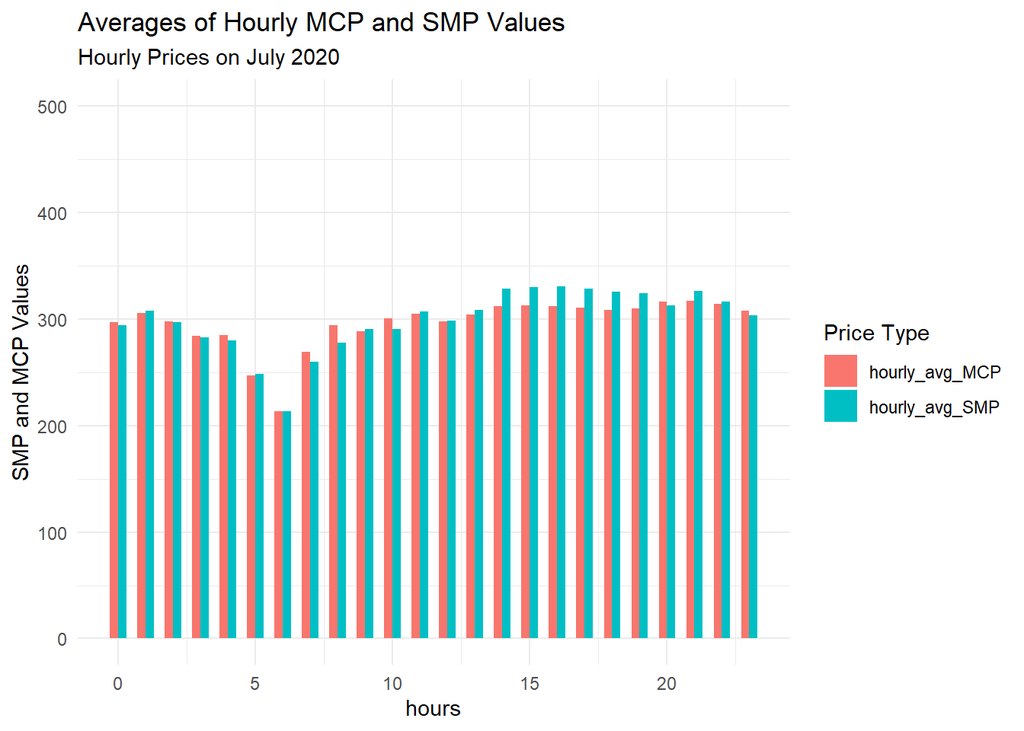

```r
  new_data4<- new_data3 %>%
  select(hour,hourly_avg_MCP,hourly_avg_SMP) %>%
  pivot_longer(.,-hour)
  #new_data4

  bar_plot<-ggplot(new_data4) + geom_col(aes(hour,value,fill=name),width=0.6,position="dodge")

  bar_plot2<-bar_plot+theme_minimal()

  bar_plot3 <- bar_plot2 + labs(x="hours", y="SMP and MCP Values",fill="Price Type", title = "Averages of Hourly MCP and SMP Values", subtitle = "Hourly Prices on July 2020") +ylim(0,500)

bar_plot3
```

**4.2.** Finally, we can see the percentage changes of the hourly average of MCP and SMP values!

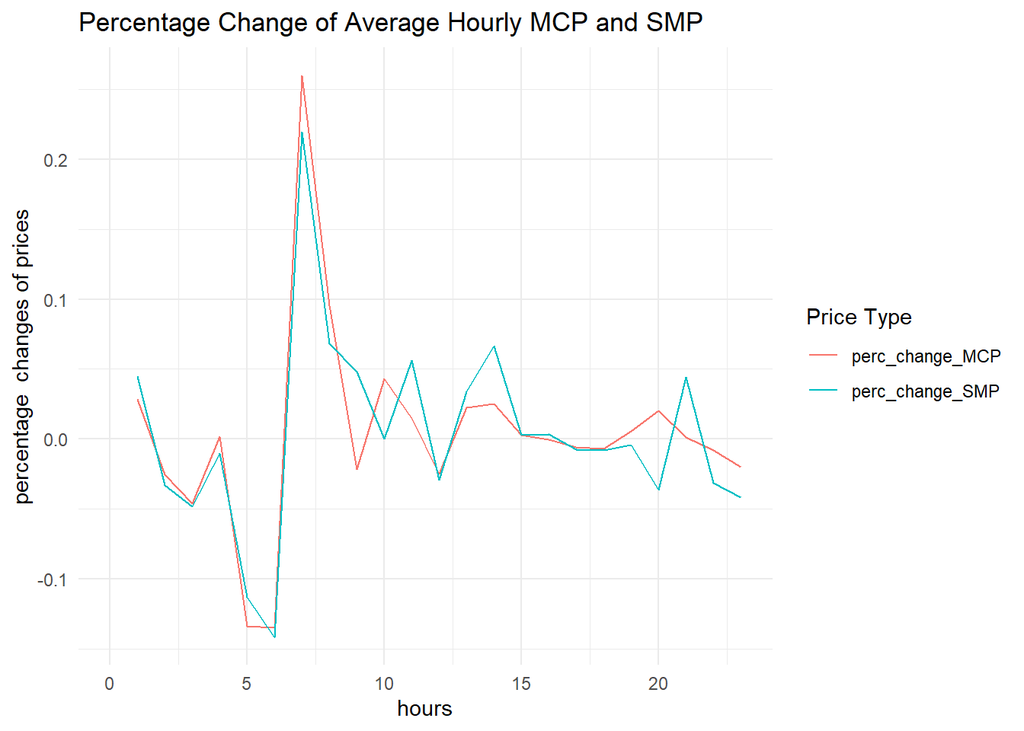

```r
 new_data5<- new_data3 %>%
  select(hour,perc_change_MCP,perc_change_SMP) %>%
  pivot_longer(.,-hour)

#new_data5


line_plot3<-ggplot(new_data5,aes(hour,value,color=name))+geom_line()+
theme_minimal()
line_plot3 <- line_plot3 + labs(x="hours", y="percentage  changes of prices",color="Price Type", title = "Percentage Change of Average Hourly MCP and SMP")

line_plot3
## Warning: Removed 2 row(s) containing missing values (geom_path).
```

From the line_plot, we can observe that percentage change of both hourly average SMP and MCP are correlated most of the time, and the change increase in both of them can be observed between 06.00 A.M and 10.00 A.M.